# scider: Single-Cell Investigation of Donor Expression Reproducibility

Michael Cole

2017-08-05

# 1 Introduction

As single-cell technologies mature and push the boundaries of study resolution and scale, they promise to enrich our understanding of several complex biological systems. In the context of human disease, studies of single donors may prove very fruitful in the characterization and cataloging of diverse cell states. While single-subject studies can be used to generate bold hypotheses, these approaches do not guarantee results applicable to other individuals with one or more related phenotypes. More generally, if the goal of an analysis is to predict phenomena linked to a specific phenotype - in humans, mice, or other models with unknown or uncontrolled sources of variation - it is important to prioritize reproducibility across multiple sources.

In this vignette, we will step through an analysis of single-cell RNA-Seq (scRNA-Seq) data collected from 3 human donors. In `Section 2`, we model coarse-grained structures in the expression data, discussing the problem of clustering cells across multiple donors. In `Section 3`, we begin to leverage donor information in order to identify “reproducible gene modules” - axes of expression variation that are common to all (or a subset of) individuals. `Section 4` introduces quantitative tools - based on the Irreproducible Discovery Rate (Q. Li et al. 2011), for assessing signal reproducibility across donors. `Section 5` summarizes additional tools for IDR-based and IDR-free meta-analysis applicable to multi-donor studies. Finally, `Section 6` describes lower-level utilities for monitoring reproducibility across donors.

## 1.1 The Data Set: Conventional Dendritic Cells (cDCs) in Elite Controllers (ECs)

The sheer diversity of factors that influence complex biological specimens typically results in several uncontrolled axes of experimental variation. When considering samples from human donors (and even those isolated from model systems such as mice), differences, for example, in genetics, behavior, exposure, environment, and/or collection point, can confound computational analyses that seek to identify and prioritize putative shared features. Here, we present a generally applicable framework, based on Irreproducible Discovery Rate (IDR), for nominating elements that are reproducibly shared across contrasts (i.e., groupings).

More specifically, in this vignette, we consider a scRNA-Seq data set of cells collected from 3 Elite Controllers (ECs) – HIV-infected individuals with undetectable levels of circulating viremia. Previously, EC innate immune conventional dendritic cells (cDCs) have been shown to exhibit enhanced antiviral responses but the underlying mechanisms driving this cDC functional phenotype, the fraction of EC cDCs that assume it, and the biomarkers that enrich for it are unknown (for additional details, see accompanying manuscript Gayo et al., 2017)(Walker and Yu 2013). In order to examine these questions, we exposed peripheral blood mononuclear cells (PBMCs) from each EC donor to pseudotyped HIV-1 for 48 hours ex vivo, and then isolated single cDCs and performed Smart-Seq2-based scRNA-Seq (Picelli et al. 2013). As a control, matched PBMCs were exposed to media alone for the same period of time and processed.

Below, we load normalized and log-transformed scRNA-Seq expression estimates (see Gayo et al., Supplementary Information for additional details).

```r
table_dir =  paste0(
  "~/Dropbox/",
  "2016 Gayo Single Cell DC HIV/",
  "NBT Submission/",
  "Submission Files/Tables/"
  )

# Load scRNA-Seq (Normalized and log-transformed)
df_meta = read.xlsx(xlsxFile = paste0(table_dir,
                                 "Gayo_NBT_Table_S1.xlsx"))
df_expr = read.xlsx(xlsxFile = paste0(table_dir,
                                 "Gayo_NBT_Table_S2.xlsx"))

is_late = df_meta$timepoint == "48H"
donor = factor(df_meta$patient[is_late])
lexpr = t(as.matrix(df_expr[is_late,-1]))
colnames(lexpr) = df_expr[is_late,1]
lexpr = lexpr[apply(lexpr, 1, var) > 0, ]
```

# 2 Clustering Across Donors

When performing single-cell analyses of multiple donors, it is often important to compare cells across them - i.e., to quantify the extent to which samples from different donors contain cells that are representative of the “same” cell state. While there may be biologically meaningful differences in gene expression between fundamentally similar cells collected from different subjects (due to unknown or uncontrolled axes of variation such as genetics, treatment history, environment or the like), characterizing and accounting for those differences can be a challenging task, especially when cells are viewed on a high-dimensional expression manifold. For example, some cell states may be represented in greater or lesser numbers across donors, while others may be unique to specific donors. Additionally, there may be batch effects due to subtle technical differences in extraction and/or sample processing. Any effort to decouple these latter technical contributions requires careful consideration, and the data adjustments necessary for removing technical artifacts are beyond the scope of this vignette (for a thorough treatment, see the `scone` package on [Bioconductor](http://bioconductor.org/packages/scone/)). The expression estimates used in this vignette were generated via RSEM (B. Li and Dewey 2011), accounting for read depth. The data was processed further via quantile normalization in order to address other quality control considerations. A complete discussion of methods and motivations can be found in the Supplementary Information of Gayo et al. 2017.

## 2.1 Partitioning Around Medoid (PAM) Clustering via Dimension Reduction

If expression data from multiple batches has been properly normalized, we may attempt to relate cell expression profiles to each other based on their pairwise distances. In high-dimensional data such as these, many axes of variation are random and noisy – that is, they do not inform (and may potentially misinform) us of the underlying cell state. Dimension reduction techniques, such as Principal Components Analysis (PCA), allow us to represent the data with a smaller number of features with high signal-to-noise ratios. Distances computed on these features may be used to partition or cluster cells according to cell state.

Partitioning Around Medoid (PAM) is a clustering algorithm that searches for a set of `k` medoids spanning the data set, mapping each cell to a cluster represented by the closest medoid. Because the number of clusters, `k`, is unspecified at the beginning of an analysis, it is common to choose a value of `k` that maximizes the “overall average silhouette width” - that is, the average over all sample “silhouette” values, which quantify the extent to which a sample clusters with its own cluster over others. This procedure is implemented in `pamk` exported by the `fpc` package.

The `pamkd` function, introduced here, performs Partitioning Around Medoid (PAM) clustering over a range of clusters, similar to `pamk`, but it examines a range of principal components, varying the dimensions over which distances are computed. After clustering over a range of PCs (dimensions), this function selects a dimension for the data that maximizes the cluster number. This maximal cluster criterion biases the analysis to a representation with the largest possible number of clusters constrained by the conditional `pamk` objective; `pamkd` will fail in the absence of tight clusters, spuriously selecting large or maximal values of `k`. Therefore, the results of this method should only be applied when its selections are robust with respect to varying `maxk` or `maxd`.

```r
pamkd_obj = pamkd(
  lexpr,
  maxk = 10,
  maxd = 50,
  to_log = FALSE,
  pca_center = TRUE,
  pca_scale = TRUE
)
```

In the call above, we have set the following argument values:

- `maxk` = 10. Consider a maximum of 10 PAM clusters.
- `maxd` = 50. Consider a maximum of 50 Principal Components (PCs).
- `to_log` = FALSE. Data is already log-transformed.
- `pca_center` = TRUE. Expression data rows (genes) are centered for PCA.
- `pca_scale` = TRUE. Genes are scaled to unit variance for PCA.

Inspecting the output, under the `pamobject` return value, we see that `pamkd` identified 5 clusters across the 3 donors.

```r
table(pamkd_obj$pamobject$clustering,
      donor)
```

```
##    donor
##      P1  P2  P3
##   1  15  41 164
##   2  27   3   5
##   3  16   0   0
##   4   3  11   7
##   5   1  12  13
```

Interestingly, only one cluster, cluster `3`, is unique to any donor; in other analyses, there could be many more donor (or donor subset)-specific clusters. Cells like cluster 3 may be present in other donors, and single-donor analyses could be used to generate candidate markers for additional experimental exploration. However, the focus of the present analysis is the space of reproducible phenomena – in this instance, features common to EC cDCs.

## 2.2 Visualizing Results with tSNE

One advantage of the simultaneous `k` and `d` selection above is that we are left with a small number of PCs that are well-suited for non-linear dimension reduction techniques that are designed for visual representation (e.g. tSNE).

```r
tsne_obj = Rtsne(pamkd_obj$Y,
                        pca = FALSE,
                        max_iter = 5000,
                        verbose = FALSE)
```

Because 7 PCs optimally resolved the five clusters reported by `pamkd`, we expect further dimension reduction techniques to preserve that clustering. Therefore, tSNE provides us with a 2-dimensional representation of clustering in 7-dimensions. Below we can see that tSNE faithfully represents our clusters. In the plot below we have reordered cluster names to match the main manuscript.

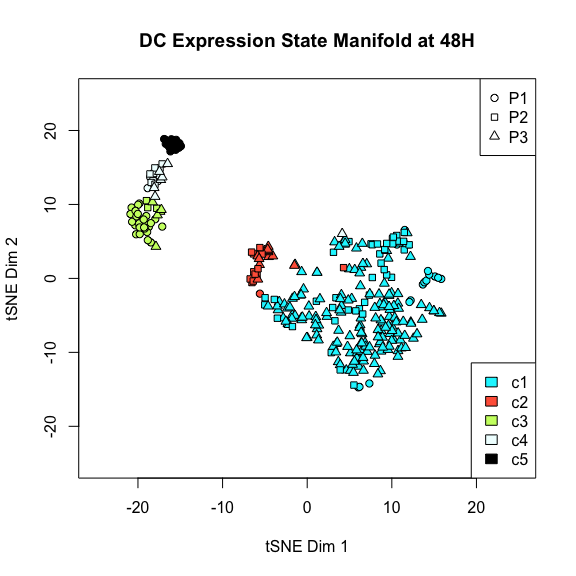

```r
donor_pchs = c(21, 22, 24)
cluster_cols = c("turquoise1",
                 "darkolivegreen1",
                 "black",
                 "azure1",
                 "tomato1")

plot(
  tsne_obj$Y,
  xlim = c(-25, 25),
  ylim = c(-25, 25),
  pch = donor_pchs[as.numeric(donor)],
  bg = cluster_cols[pamkd_obj$pam$clustering],
  main = "DC Expression State Manifold at 48H",
  xlab = "tSNE Dim 1",
  ylab = "tSNE Dim 2"
)

legend("topright",
       pch = donor_pchs,
       legend = paste0("P", 1:3))

o = c(1, 3, 5, 4, 2) # Alternative cluster labels
clustering = paste0("c", o[pamkd_obj$pam$clustering])

legend(
  "bottomright",
  fill = cluster_cols[order(o)],
  legend = paste0("c", 1:5)
)
```

# 3 Reproducible Gene Modules

Given access to multiple samples of homologous single-cell populations, it may be important to identify common sets of co-varying genes or “reproducible gene modules.” Reproducibly correlated gene modules may inform us of novel biological mechanisms that drive these systems.

If cell populations are heterogeneous, this kind of analysis may naturally follow a clustering step, uncovering reproducible modes of intra-cluster variation. Alternatively, reproducible correlation analysis may be done separately from clustering analysis altogether; reproducible modules can then serve as the basis for a reproducible inter-cluster manifold. We will consider this latter approach in this section.

The `scider` package facilitates a three-step reproducible gene module analysis. The first step involves identifying gene-gene pairs that are “reproducibly correlated,” generating a gene-gene adjacency matrix. We will first consider a simple threshold-based reproducibility criterion and turn to other options later in the vignette. The second step is hub-identification in the reproducible gene-gene graph. The goal of this step is to identify genes that play critical roles in the reproducible co-variance structure. The third step involves clustering hub genes into “reproducible modules.”

## 3.1 Defining a Reproducible Gene-Gene Adjacency Matrix

In the first step or our analysis, we use `get.repro.thresh.adjacency` to generate a gene-gene adjacency matrix based on a simple correlation threshold criterion.

```r
A = get.repro.thresh.adjacency(x = lexpr,
                               r = donor,
                               pair_pthresh = 0.01474)
```

In the call above, we have set the following argument values:

- `x` = log expression data used for computing Pearson correlations.
- `r` = donor. Correlation matrices will be separately computed across all three donors.
- `pair_pthresh` = 0.01474. Precisely 2 times the normal CDF of the opposite of the 95% normal quantile divided by the 75% normal quantile. Following z-scaling of donor upper-triangular correlation matrices, a pair will be called “reproducible” if its z-value corresponds to a 2-tailed p-value below this threshold. This threshold was use to generate the plots in Gayo et al. 2017, though primary results are the same for similar choices of threshold.

If a gene-pair’s p-value falls below `pair_pthresh` in all donors, an undirected edge is drawn between the two genes. Due to the small number edges expected in this matrix, the result is returned in a sparse matrix format.

## 3.2 Hub Identification

The `pzipdegree` function is a simple tool for hub identification based on a Poisson model of vertex degree: this degree distribution would result from independent and uniform edge probabilities in the case of many genes. Our model includes a zero-inflated component to represent noisy genes with correlations consistently below threshold. `pzipdegree` takes an `igraph` object as its argument, returning upper-tail p-values under the null model.

```r
# Create igraph object from adjacency matrix
g = graph.adjacency(A,mode = "undirected")

is_hub = p.adjust(pzipdegree(g), method = "bonferroni") < 0.01
table(is_hub)
```

```
## is_hub
## FALSE  TRUE
##  7875   263
```

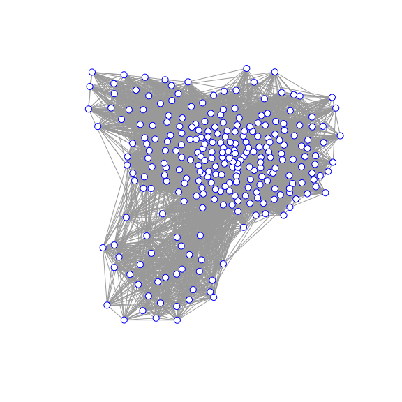

```r
# Create igraph object representing sub-graph of hub genes
g_hub = graph.adjacency(A[is_hub,is_hub],mode = "undirected")

plot(g_hub, vertex.size = 5, vertex.color = "white",
     layout = layout.fruchterman.reingold(g_hub),
     vertex.label = "",
     vertex.shape = "circle",
     vertex.frame.color = "blue")
```

## 3.3 Hub Clustering and Reproducible Module Annotation

In the last step of our reproducible module analysis, we aim to cluster hub genes into reproducible modules. `scider` provides no tools for this step, but we may rely on other common libraries as there are many ways to cluster genes based on their correlation sub-matrix. For example, we could have added weights to the graph above, based on donor-averaged gene-gene correlation measures. Several `igraph` functions could then be used with the resulting graph in order to identify communities of hubs.

To illustrate a simple example below, we use the `stats` package to perform complete hierarchical clustering on the median hub-hub correlation matrix: the element-wise median of all donor-specific hub-hub correlation matrices. We compute distances between genes by computing correlations of correlations: genes with similar correlations to other genes are placed close together according to this metric.

```r
# Compute hub-hub correlations per donor
rep_cor_list = sapply(levels(donor),
                      simplify = FALSE,
                      function(p) {
                        cor(t(lexpr[is_hub,
                              donor == p]))
                        })

# Median hub correlation matrix
mediancor = apply(simplify2array(rep_cor_list), 1:2, median)

# Median hub correlation matrix
hc = hclust(dist(1 - cor(mediancor,
                         method = "pearson")),
            method = "complete")
hub_clustering = factor(paste0("m",cutree(hc, k = 3)))

table(hub_clustering)
```

```
## hub_clustering
##  m1  m2  m3
## 160  71  32
```

Setting the number of modules to three - motivated by observations above - we find one large module and two smaller modules. Visualizing the median correlation below, three appears to be a reasonable selection of module number:

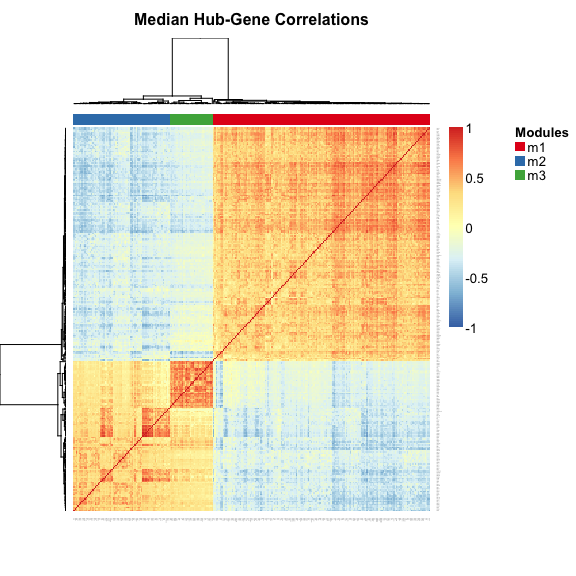

```r
module_cols <- brewer.pal(3, "Set1")

aheatmap(
  main = "Median Hub-Gene Correlations",
  mediancor,
  breaks = 0,
  annCol = list(Modules = hub_clustering),
  annColors = list(Modules = module_cols),
  distfun = "correlation",
  hclustfun = "complete"
)
```

Module `m1` is anti-correlated with both `m2` and `m3`, but `m3` forms a uniform sub-module. When we visualize the three donor-specific correlation matrices separately we can see that `m1` is very robust, while the contrast between `m2` and `m3` softens between donors.

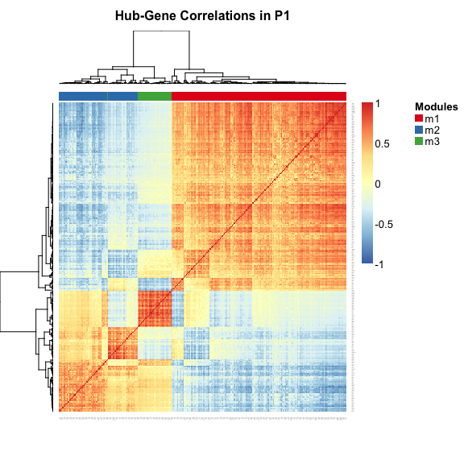

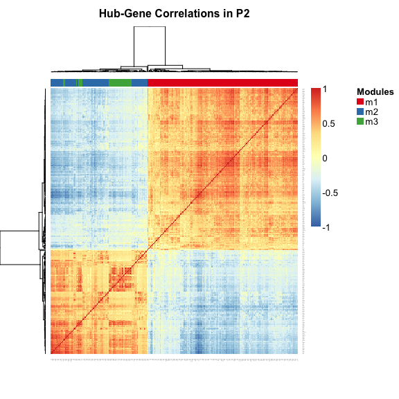

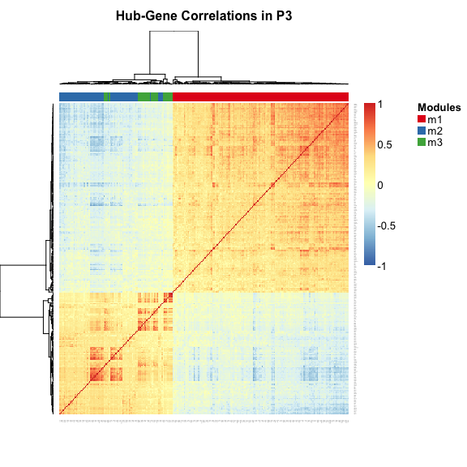

```r
hm_list = sapply(levels(donor),
       function(p) {
         aheatmap(
           main = paste("Hub-Gene Correlations in",p),
           rep_cor_list[[p]],
           breaks = 0,
           annCol = list(Modules = hub_clustering),
           annColors = list(Modules = module_cols),
           distfun = "correlation",
           hclustfun = "complete"
         )
       }
)
```

## 3.4 Reproducible Inter-Cluster Manifold

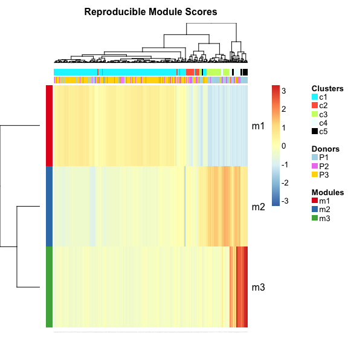

```r
# Define module score as mean of expression z-scores
module_scores = t(aggregate(t(apply(
  lexpr[is_hub, ], 1, scale
)),
by = list(hub_clustering),
FUN = mean)[, -1])

aheatmap(t(module_scores),
         main = "Reproducible Module Scores", labRow = levels(hub_clustering),
         breaks = 0, annCol = list(Clusters = clustering, Donors = donor),
         annRow = list(Modules = factor(levels(hub_clustering))),
         annColors = list(Clusters = cluster_cols[order(o)],
                          Donors = c("lightblue","violet","gold"),
                          Modules = module_cols)
  )
```

We can also visualize this three-dimensional data in a 2-dimensional representation below.

```r
# 2D tSNE on module scores
tsne_obj_hub = Rtsne(module_scores,
                     pca = FALSE,
                     max_iter = 5000,
                     verbose = FALSE)
```

Below we can see that this “reproducible” tSNE manifold is different from the original above. There is a smoother transition from `c1` to `c2`, `c3`, and on to a merged `c4-5` cluster. This gradual progression is one motivation for focusing on extreme clusters (not `c2`) for differential expression analysis (see Gayo et al. 2017).

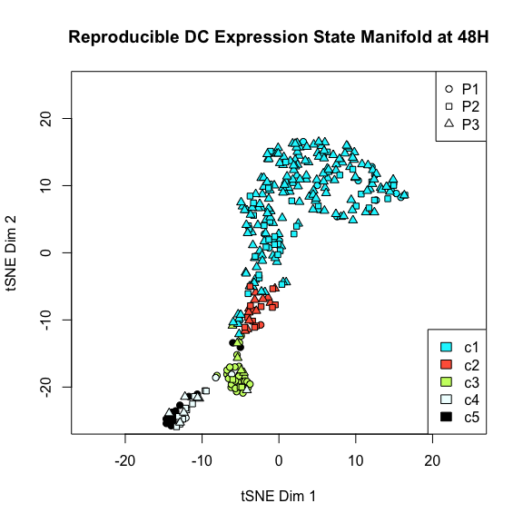

```r
plot(
  tsne_obj_hub$Y,
  xlim = c(-25, 25),
  ylim = c(-25, 25),
  pch = donor_pchs[as.numeric(donor)],
  bg = cluster_cols[pamkd_obj$pam$clustering],
  main = "Reproducible DC Expression State Manifold at 48H",
  xlab = "tSNE Dim 1",
  ylab = "tSNE Dim 2"
)

legend("topright",
       pch = donor_pchs,
       legend = paste0("P", 1:3))

legend("bottomright",
       fill = cluster_cols[order(o)],
       legend = paste0("c", 1:5))
```

# 4 Reproducibility-Based Differential Expression and Signature Analyses

At this point in our analysis, we are beginning to study gene-level phenomena. For example, we may start to quantify the extent to which transcripts are up- or down-regulated in `c1` cells vs `c3-5` cells. How do we begin to address patient variability? For example, how do we find expression differences common to `c1` cells across donors? In this section, we will first consider a traditional method for modeling donor biases in the context of differential expression. Then we will contrast modeling results to the results of IDR analysis as outlined in (Q. Li et al. 2011) while discussing our contribution to pre-existing IDR tool set.

Following our discussion of differential expression, we will demonstrate the generalizability of `scider` IDR tools by applying them to two different signature analyses.

## 4.1 Linear Models of Differential Expression

Our first (traditional) method models the log-expression of each gene with gene-specific linear models. For each gene, we estimate a separate offset, cluster effect (`c1` vs `c3-5`), and donor effects (`P1` or `P2` vs `P3`) to model the expression of that gene across all cells in the study occupying the extreme clusters, excluding cells in `c2` as explained in 3.4 above.

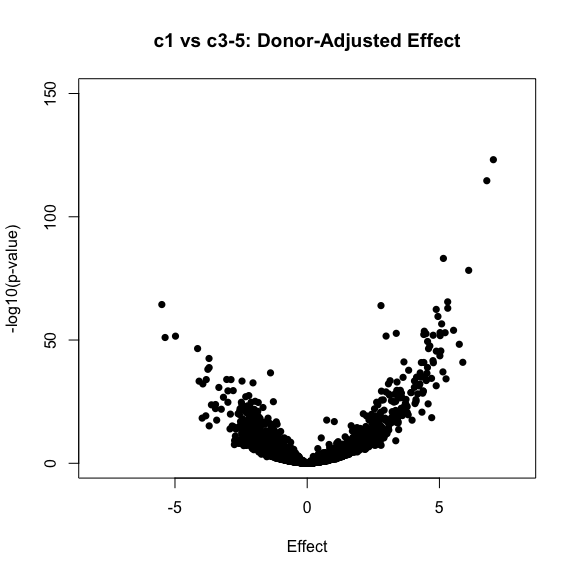

```r
# Dependent and independent variables
is_included = !clustering %in% "c2"
x = lexpr[, is_included]
g = factor(c("c1",NA,rep("c3-5",3))[factor(clustering)])[is_included]
r = donor[is_included]

# One fit per gene
bio_effect_results = data.frame(t(apply(x, 1,function(y){
  coefficients(summary(lm(y ~ g + r)))["gc3-5",c("Estimate","Pr(>|t|)")]
  })),row.names = rownames(x))
colnames(bio_effect_results) = c("Estimate","p")

plot(-bio_effect_results$Estimate,
     -log10(bio_effect_results$p),
     main = "c1 vs c3-5: Donor-Adjusted Effect",
     xlab = "Effect", ylab = "-log10(p-value)",
     pch = 16, xlim = c(-8,8), ylim = c(0,150))
```

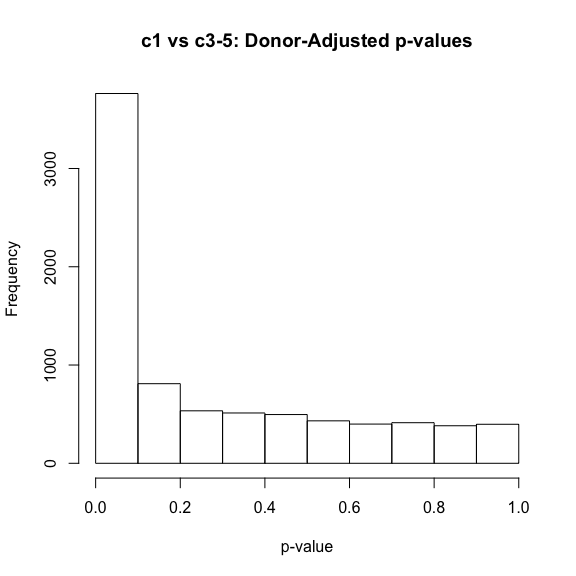

```r
hist(bio_effect_results$p,
     main = "c1 vs c3-5: Donor-Adjusted p-values",
     xlab = "p-value")
```

The histogram above shows how the distribution of p-values is skewed heavily toward low values. This is not particularly surprising given that cell clustering is based on the expression data itself.

A notable limitation of this simple model is that it does not include interactions between donor and cluster: not only can there be no attribution of donor-specific differential expression effect, but there is no notion of “common” effect being modeled. As we will show, this distinction can be treated quantitatively with IDR meta-analysis.

## 4.2 Irreproducible Discovery Rate (IDR)

Rather than simply identifying genes that show significant evidence of differential expression, we may wish to emphasize differential expression that is “reproducible” across donors. The IDR framework (Q. Li et al. 2011) outlines methods for comparing results of replicate analyses: e.g., differential expression analyses performed separately for each donor. Given a list of significance scores (e.g. -log(p-value)), for each donor, we can fit tests to a 2-component mixture model: tests are either part of an irreproducible component (in which significance rank is uncorrelated across donors) or part of a reproducible one (in which significance rank is correlated and higher on average).

`kruskalIDRm` is a function for stratified gene-level tests of association (Kruskal-Wallis H test), followed by IDR analysis on the resulting -log(p-value) matrix. Arguments to this function include:

- `x`: the (log-) expression matrix to be tested.
- `r`: replicate groups under which association tests are performed.
- `g`: groups of cells to be compared with respect to every gene.

Due to small numbers of cells in the first two donors, the analysis presented in our manuscript pooled cells from donors `P1` and `P2` in order to form two replicate groups: `P12` and `P3`. Note that IDR tools implemented in the CRAN [idr](https://cran.r-project.org/web/packages/idr/index.html) package are designed to analyze only 2 replicates, a limitation we address below.

```r
r = factor(c(rep("P12",2),"P3")[donor[is_included]])
idrm_kruskal_pool = kruskalIDRm(x, r, g)
```

The resulting list contains the (named) p-value matrix from differential expression tests, an object containing all IDR results, and a logical indicating which genes were included in the DE analysis; low-gene variance genes are filtered at the earliest stage. We can access the gene-level IDR estimates for all genes that were tested, by accessing the IDR analysis element, `idr`:

```r
IDR = idrm_kruskal_pool$idr$IDR
names(IDR) = rownames(
  idrm_kruskal_pool$kruskal_pvals)[idrm_kruskal_pool$is_replicated]
```

Similar to a false-discovery rate (FDR), IDR values correspond to the cumulative fraction of irreproducible tests (genes) for genes of less or equal irreproducible component membership probability.

Below, we plot the relationship between IDR values and Bonferroni-adjusted t-test p-values from the section above.

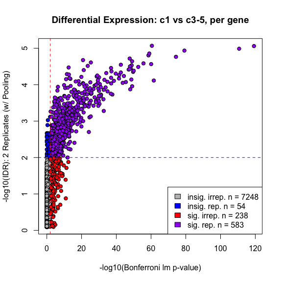

```r
lm_pvals_adjust = p.adjust(bio_effect_results[names(IDR),]$p,
                           method = "bonferroni")

gtype = factor(paste((-log10(lm_pvals_adjust) > 2), (-log10(IDR)  > 2)))
gcols = c("grey", "blue", "red", "purple")[gtype]

plot(
  -log10(lm_pvals_adjust),
  -log10(IDR),
  pch = 21,
  bg = gcols,
  main = "Differential Expression: c1 vs c3-5, per gene",
  xlab = "-log10(Bonferroni lm p-value)",
  ylab = "-log10(IDR): 2 Replicates (w/ Pooling)"
)
abline(v = 2, col = "red", lty = 2)
abline(h = 2, col = "blue", lty = 2)
legend(
  "bottomright",
  legend = paste(
    c("insig. irrep.", "insig. rep.", "sig. irrep.", "sig. rep."),
    "n =",
    table(gtype)
  ),
  fill = c("grey", "blue", "red", "purple")
)
```

We can see that 29% of the genes that are called as significantly differentially expressed (adjusted p-value < 0.01) are not reproducibly so (IDR < 0.01). These genes are differentially expressed, but they do not vary consistently across the 2 cell pools - i.e. a gene may be differentially expressed in one but not the other. The gene could also be differentially expressed in both pools, but the rank of the difference varies substantially between pools:

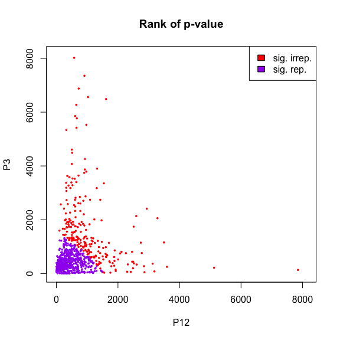

```r
rank_matrix = apply(idrm_kruskal_pool$kruskal_pvals[names(IDR), ],
                    2, rank)
plot(
  rank_matrix[as.numeric(gtype) %in% c(3, 4), ],
  main = "Rank of p-value",
  pch = 16,
  cex = .5,
  xlim = range(rank_matrix),
  ylim =  range(rank_matrix),
  col = gcols[as.numeric(gtype) %in% c(3, 4)]
)
legend(
  "topright",
  legend =
    c("sig. irrep.", "sig. rep."),
  fill = c("red", "purple")
)
```

On the other hand, only 8% of genes that exhibit reproducible p-value rank fall below our significance threshold. The presence of more tests like this (i.e., a higher fraction) could suggest that the significance threshold is too stringent or that there is an issue with the underlying null model used for computing p-values. Beyond the small number of insignificant reproducible tests, the IDR criterion appears to be stricter than our significance criterion, selecting a smaller set of tests with uniform results across replicate pools.

## 4.3 IDR with Many Replicates

In the `scider` package we have modified code from the CRAN [idr](https://cran.r-project.org/web/packages/idr/index.html) package to handle more than 2 replicates, as prescribed in the authors’ original manuscript. The many-replicate `est.IDRm` function implemented in `scider` is adapted from the 2-replicate `est.IDR` in `idr`, including some new error messages.

Using this broader functionality, we may choose to perform a similar analysis as in the previous subsection, but treat each donor as a replicate pool.

```r
r = donor[is_included]
idrm_kruskal = kruskalIDRm(x, r, g)
```

How do our results change when treating `P1` and `P2` as replicate pools? Due to gene filtering, there may be a few genes that are absent from the 3-way analysis; we will only consider the intersection of genes from both.

```r
# Unpacking IDR values for many replicates
IDRm = idrm_kruskal$idr$IDR
names(IDRm) = rownames(idrm_kruskal$kruskal_pvals)[idrm_kruskal$is_replicated]

# Subsetting IDR values over shared tests
genes_shared = intersect(names(IDR), names(IDRm))
IDR = IDR[genes_shared]
IDRm = IDRm[genes_shared]
```

Below we plot log-transformed IDR values from both analyses:

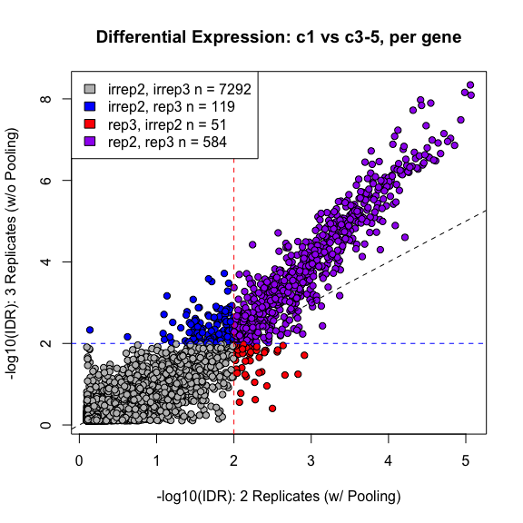

```r
gtype0 = factor(paste((-log10(IDR) > 2), (-log10(IDRm)  > 2)))
gcols0 = c("grey", "blue", "red", "purple")[gtype0]

plot(
  -log10(IDR),
  -log10(IDRm),
  pch = 21,
  bg = gcols0,
  main = "Differential Expression: c1 vs c3-5, per gene",
  xlab = "-log10(IDR): 2 Replicates (w/ Pooling)",
  ylab = "-log10(IDR): 3 Replicates (w/o Pooling)"
)
abline(v = 2, col = "red", lty = 2)
abline(h = 2, col = "blue", lty = 2)
abline(0, 1, lty = 2, col = "black")
legend(
  "topleft",
  legend = paste(
    c("irrep2, irrep3", "irrep2, rep3", "rep3, irrep2", "rep2, rep3"),
    "n =",
    table(gtype0)
  ),
  fill = c("grey", "blue", "red", "purple")
)
```

Above we can see that there are slightly more reproducible tests called in the 3-way analysis. Notice also that the most reproducible tests are assigned greater membership probability to the reproducible component in the new analysis (above the y = x diagonal).

# 5 Biomarker and Signature Analyses

Before diving into low-level IDR analysis methods in the last section, we will discuss additional high-level analyses that can be implemented using `scider` tools, including new examples of general IDR-based analyses and meta-analysis.

## 5.1 Marker Prediction

In Gayo et al. 2017, we nominate potential biomarkers for sub-populations by synthesizing multiple analyses. First, we consider the set of hub genes that are differentially-expressed between our target population, `c1`, and extreme populations `c3-c5`. The hub condition requires that the transcript shows robust and reproducible co-expression with many other genes, while the second differential expression condition requires specificity. Then, lists of hub genes and differentially expressed genes are intersected with a list of transcripts encoding known surface markers in order to generate a final list of candidates.

The `getMarkers` function implements all of these pieces, including IDR-based differential expression analysis and reproducible hub identification. The code below can be used to reproduce the marker prediction from our main analysis.

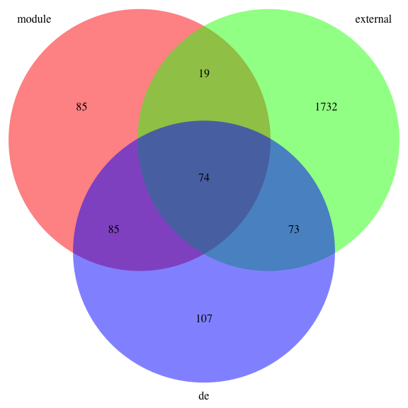

```r
x = lexpr
g = factor(c("c1",NA,rep("c3-5",3))[factor(clustering)])
r = donor
r_de = factor(c(rep("P12",2),"P3")[donor])

# Loading external marker list
search_page = "http://www.proteinatlas.org/search"
search_terms = "protein_class%3APredicted+membrane+proteins"
query_format = "format=tab"
dbdat = read.table(
  paste0(search_page,"/",search_terms,"?",query_format),
           sep = "\t",quote = "", header = TRUE)
external_markers = intersect(as.character(dbdat$Gene),rownames(x))

markers = getMarkers(x = x, r = r, r_de = r_de, pair_pthresh = 0.01474,
                 g = g, g_target = "c1",
                 external_markers = external_markers,
                 plot_venn = TRUE)
```

While `x`, `r`, `g` and `pair_pthresh` hold the same meaning as in other functions, there are a couple new arguments:

- `r_de`: Both the hub analysis and differential expression analysis require a replicate (`r`) argument, but they need not be the same. If `r_de` is specified, it is passed to `kruskalIDRm` as the `r` argument.
- `g_target`: `kruskalIDRm` returns measures of significance and reproducibility, but it does not assign directionality of differential expression. By specifying this argument, we will only consider genes/transcripts that exhibit average up-regulation in the target `g` level.

The Venn diagram above summarizes the output list of gene sets for visual inspection:

```r
# Print head of each list
lapply(markers,head)
```

```
## $de_names
## [1] "ACP2"     "ADAMTSL4" "ADAP2"    "ADGRE2"   "AGTRAP"   "AIF1"
##
## $module_names
## [1] "ADAMTSL4" "AIF1"     "ALAS1"    "ANKRD22"  "ANPEP"    "ANXA2"
##
## $external_markers
## [1] "AACS"   "AASDH"  "ABCA7"  "ABCB7"  "ABCC1"  "ABCC10"
##
## $marker_names
## [1] "ANPEP"   "ATP6AP1" "ATP6V0C" "C5AR1"   "CCR1"    "CCR5"
```

## 5.2 Other IDR Applications: Identification of upstream regulators

In the previous section, we applied the IDR framework to differential expression, often identifying tests with genes or transcripts. In this section, we will explore how these methods can be applied to other kinds of signals, such as gene signatures defined from related data sets.

Consider the shRNA-knockdown nanostring data set collected by Chevrier et al. 2011 (Chevrier et al. 2011). In the accompanying study, the investigators considered the effect of knocking down signaling regulators, transcriptional regulators, and Plk-dependent phosphoproteins on the mRNA expression of mouse bone-marrow-derived dendritic cells (BMDCs). Normalized nanostring expression data for 128 genes can be downloaded from the NCBI manuscript [website](https://www.ncbi.nlm.nih.gov/pmc/articles/PMC3809888/).

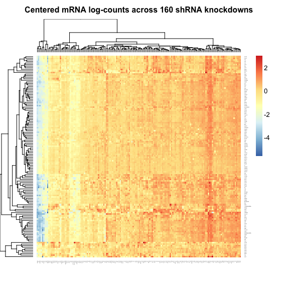

```r
urls = paste(paste0("http://www.ncbi.nlm.nih.gov/pmc/articles/",
  "PMC3809888/bin/NIHMS350287-supplement-Table"),
  c("S2.xls", "S7.xls"), sep = "_")
sheet_index = c(2, 3)
shrna_counts = do.call(cbind,
                       lapply(1:2, function(s) {
                         df = read.xls(urls[s], sheet = sheet_index[s])
                         x = as.matrix(df[,-1])
                         rownames(x) = df$Target_genes
                         x}))

aheatmap(
  log1p(shrna_counts) - rowMeans(log1p(shrna_counts)),
  main = paste("Centered mRNA log-counts across",
               ncol(shrna_counts),
               "shRNA knockdowns")
  )
```

In the visualization above, we have centered each of the rows (assayed genes) so as to make them comparable. Because these are mouse genes, we will need to map them to human genes in order to generate expression signatures. This can be accomplished using the `biomaRt` package:

```r
gene_map = getLDS(
  mart = useMart("ENSEMBL_MART_ENSEMBL",
                dataset = "mmusculus_gene_ensembl",
                host = "jul2015.archive.ensembl.org"),
  attributes = "mgi_symbol",
  filters = "mgi_symbol", values = rownames(shrna_counts),
  martL = useMart("ENSEMBL_MART_ENSEMBL",
                dataset = "hsapiens_gene_ensembl",
                host = "jul2015.archive.ensembl.org"),
  attributesL = "hgnc_symbol",
  filtersL = "hgnc_symbol", valuesL = rownames(lexpr)
)

# Select expression sub-matrices for uniquely mapped genes
uniq_gene_map = gene_map[apply(apply(gene_map,2,isUnique),1,all), ]
sc_expr = lexpr[uniq_gene_map$HGNC.symbol, ]
shrna_expr = log(shrna_counts + 1)[uniq_gene_map$MGI.symbol, ]
```

Now that we have normalized expression data mapped to human gene symbols, we can go about defining signature values for each cell in our data set. While the analysis presented in Gayo et al. 2017 relied on “weighted” signatures based on models of missing data (see Gayo et al. Supplementary Information), here, we use a simple signature equal to the opposite of the correlation between centered single-cell and nanostring profiles. We will refer to these signatures as an “(Unweighted) Upstream Regulatory Scores” because they score the distance of a cell profile from expression profiles in which specific regulators have been inhibited.

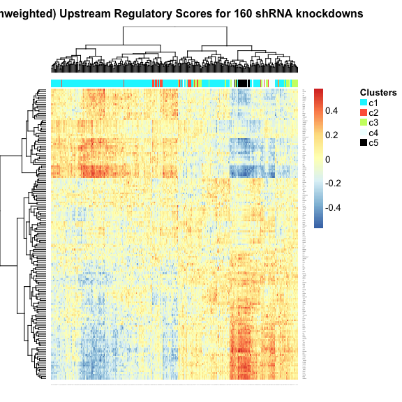

```r
upstream_scores = -cor(shrna_expr - rowMeans(shrna_expr),
    sc_expr - rowMeans(sc_expr))

aheatmap(
  upstream_scores,
  annCol = list(Clusters = clustering),annColors = list(Clusters = cluster_cols[order(o)]),
  breaks = 0,
  main = paste("(Unweighted) Upstream Regulatory Scores for",
               ncol(shrna_counts),
               "shRNA knockdowns")
  )
```

These scores may not be too meaningful in absolute terms, but differences in these signatures could hint at specific regulatory activity differences between cell populations. Testing for differences in signatures between cell population is conceptually similar to differential expression, and in some cases we may address the problem with the same tools. Below we utilize `kruskalIDRm` for differential signature analysis:

```r
is_included = !clustering %in% "c2"
x = upstream_scores[, is_included]
g = factor(c("c1", NA, rep("c3-5", 3))[factor(clustering)])[is_included]
r = factor(c(rep("P12", 2), "P3")[donor[is_included]])
idrm_kruskal_pool_shrna = kruskalIDRm(x, r, g)
```

We can visualize the results in a volcano plot. Note that TBK1 appears as one of the reproducibly up-regulated scores:

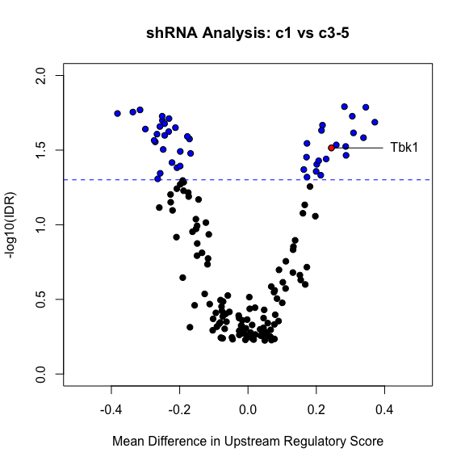

```r
# Computing Mean Differences in Scores between c1 and c3-5
mean_sigs = aggregate(t(x), by = list(cluster = g, pool = r), FUN = mean)
diff_scores = colMeans(mean_sigs[, -c(1:2)][mean_sigs$cluster == "c1", ] -
                 mean_sigs[, -c(1:2)][mean_sigs$cluster != "c1", ])

# Plot Volcano
plot(
  diff_scores[rownames(idrm_kruskal_pool_shrna$kruskal_pvals)],
  -log10(idrm_kruskal_pool_shrna$idr$IDR),
  pch = 21,
  bg = c("black","blue")[1 + (idrm_kruskal_pool_shrna$idr$IDR < 0.05)],
  main = paste("shRNA Analysis: c1 vs c3-5"),
  ylab = "-log10(IDR)",
  xlim = c(-0.5, 0.5),
  ylim = c(0, 2),
  xlab = "Mean Difference in Upstream Regulatory Score"
)

abline(h = -log10(0.05),
       lty = 2,
       col = "blue")

# Label Tbk1
is_tbk1 = rownames(idrm_kruskal_pool_shrna$kruskal_pvals) == "Tbk1"
tbk1_x = diff_scores[rownames(idrm_kruskal_pool_shrna$kruskal_pvals)][is_tbk1]
tbk1_y = -log10(idrm_kruskal_pool_shrna$idr$IDR)[is_tbk1]
lines(c(tbk1_x,tbk1_x + 0.15),c(tbk1_y,tbk1_y))
points(tbk1_x,tbk1_y,pch = 21,bg = 2)
text(pos = 4,tbk1_x+ 0.15,tbk1_y,labels = "Tbk1")
```

## 5.3 Non-IDR Signature Meta-Analysis Utilities

IDR analysis may not feasible in some cases, including situations in which the number of tests/genes/signatures is small. In this subsection, we consider a smaller set of signatures based on a data set from [Amit et al. 2009](https://www.ncbi.nlm.nih.gov/geo/query/acc.cgi?acc=GSE17721)(Amit et al. 2009). This study analyzed mouse BMDCs perturbed by various TLR agonists, comparing expression profiles to control profiles. We can access the data using the `GEOquery` package:

```r
# Download GEO Data
options('download.file.method' = 'curl')
geo_set = suppressWarnings({suppressMessages({getGEO("GSE17721")[[1]]})})

# Aggregate by sample biotype and gene symbol
meta_data = t(simplify2array(strsplit(as.character(geo_set$title),
                                      split = ", ")))

# Perturbation and Hour
bio_type = factor(gsub("ontrol", "",
                      paste0(meta_data[, 1],"_",gsub(
                      "_.*", "h", meta_data[, 2]
                      ))))
table(bio_type)
```

```
## bio_type
##     C_0h    C_12h     C_1h    C_24h     C_2h     C_4h     C_6h     C_8h
##        1        1        1        1        1        1        1        1
## Cpg_0.5h  Cpg_12h  Cpg_16h   Cpg_1h  Cpg_24h   Cpg_2h   Cpg_4h   Cpg_6h
##        2        2        1        2        1        2        2        2
##   Cpg_8h Grd_0.5h  Grd_12h  Grd_16h   Grd_1h  Grd_24h   Grd_2h   Grd_4h
##        2        2        2        2        2        2        2        2
##   Grd_6h   Grd_8h Lps_0.5h  Lps_12h  Lps_16h   Lps_1h  Lps_24h   Lps_2h
##        2        2        2        2        2        2        2        2
##   Lps_4h   Lps_6h   Lps_8h Pam_0.5h  Pam_12h  Pam_16h   Pam_1h  Pam_24h
##        2        2        2        2        2        2        2        2
##   Pam_2h   Pam_4h   Pam_6h   Pam_8h Pic_0.5h  Pic_12h  Pic_16h   Pic_1h
##        2        2        2        2        2        2        2        2
##  Pic_24h   Pic_2h   Pic_4h   Pic_6h   Pic_8h
##        2        2        2        2        2
```

Each perturbation has been assayed over multiple time points and, sometimes, multiple times. In order to prepare the matrix for signature calculation, we will aggregate over replicates, averaging features sharing gene symbols. We will also only consider late perturbations (24 hours) and the 24-hour control in the analysis that follows. Late perturbations may be most relevant because our single cells were stimulated over the course of 2 days.

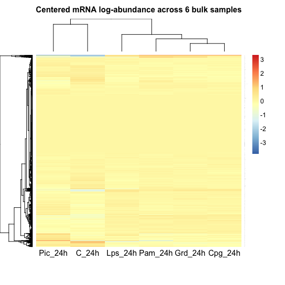

```r
# Average by gene symbol and bio type
gene_symbol = factor(featureData(geo_set)$"Gene Symbol")

tlr_array = t(aggregate(t(aggregate(
  exprs(geo_set), by = list(gene_symbol), mean
  )[, -1]), by = list(bio_type), mean)[, -1])
dimnames(tlr_array) = list(levels(gene_symbol), levels(bio_type))

# Identify unambiguous gene symbol designations
ambiguous_symbols = unique(unlist(strsplit(levels(gene_symbol)[grepl(" /// ",
                                                      levels(gene_symbol))],
                                                  split = " /// ")))
tlr_array = tlr_array[!rownames(tlr_array) %in% ambiguous_symbols,]

# Select all 24-hour samples
tlr_array  = tlr_array [, grepl("_24", colnames(tlr_array))]

aheatmap(
  log1p(tlr_array) - rowMeans(log1p(tlr_array)),
  main = paste("Centered mRNA log-abundance across",
               ncol(tlr_array),
               "bulk samples")
  )
```

As in the previous sub-section, we will need to map between mouse and human gene symbols prior to signature definition.

```r
gene_map = getLDS(
  mart = useMart("ENSEMBL_MART_ENSEMBL",
                 dataset = "mmusculus_gene_ensembl",
                 host = "jul2015.archive.ensembl.org"),
  attributes = "mgi_symbol",
  filters = "mgi_symbol",
  values = rownames(tlr_array),
  martL = useMart("ENSEMBL_MART_ENSEMBL",
                  dataset = "hsapiens_gene_ensembl",
                  host = "jul2015.archive.ensembl.org"),
  attributesL = "hgnc_symbol",
  filtersL = "hgnc_symbol",
  valuesL = rownames(lexpr)
)

# Select expression sub-matrices for uniquely mapped genes
uniq_gene_map = gene_map[apply(apply(gene_map, 2, isUnique), 1, all),]
is_withinrange = uniq_gene_map$MGI.symbol %in% rownames(tlr_array) &
  uniq_gene_map$HGNC.symbol %in% rownames(lexpr)
uniq_gene_map = uniq_gene_map[is_withinrange, ]

sc_expr = lexpr[uniq_gene_map$HGNC.symbol,]
tlr_expr = log(tlr_array)[uniq_gene_map$MGI.symbol,]
```

We will define “TLR Stimulation Scores” as the correlation between centered single-cell and array profiles, as they score the similarity of a cell profile to expression profiles in which specific TLRs have been stimulated.

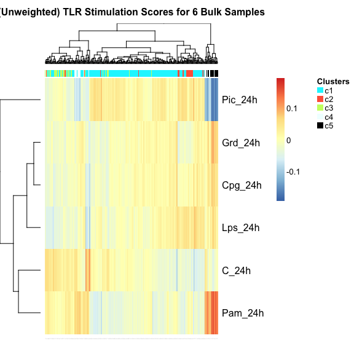

```r
stim_scores = cor(tlr_expr - rowMeans(tlr_expr),
                 sc_expr - rowMeans(sc_expr))

aheatmap(
  stim_scores,
  annCol = list(Clusters = clustering),
  annColors = list(Clusters = cluster_cols[order(o)]),
  breaks = 0,
  main = paste("(Unweighted) TLR Stimulation Scores for",
               nrow(stim_scores),
               "Bulk Samples")
  )
```

Note the similarity between this data matrix and the matrix of upstream regulatory scores: we might consider running the same type of IDR-based differential signature analysis as above. Unfortunately, the smaller number of signatures in this case can complicate the underlying statistical inference. Running the same analysis as before, we come across an error message:

```r
is_included = !clustering %in% "c2"
x = stim_scores[, is_included]
g = factor(c("c1", NA, rep("c3-5", 3))[factor(clustering)])[is_included]
r = factor(c(rep("P12", 2), "P3")[donor[is_included]])
tryCatch({idr_kruskal_pool_tlr = kruskalIDRm(x, r, g)},
         error = function(e){print(e)}
)
```

```
## <simpleError in est.IDRm(-log10(p_val_matrix[is_replicated, ]), mu = idr_mu,     sigma = idr_sigma, rho = idr_rho, p = idr_p, ...): all memberships numerically zero. try new initial params>
```

This error indicates that the IDR fit converged to a point where all tests are called irreproducible with 100% probability. As the error message suggests, we could attempt to find a set of initial parameters for which the fit converges properly; on the other hand, it may be more straightforward to consider an alternative meta-analysis approach.

The `kruskalMeta` function implements a routine similar to `kruskalIDRm`, except that it applies a standard Stouffer p-value combination rather than estimating IDR values. While this method does not address reproducibility, it is not fit based, requiring no choices of initial parameters. Below, we present an example of how to run this command and visualize the results in a volcano plot.

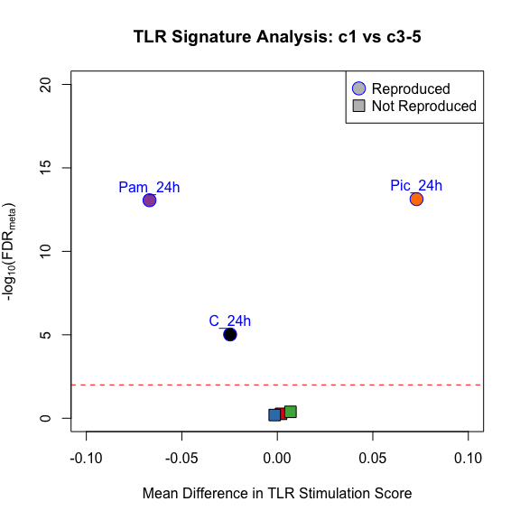

```r
meta_kruskal_pool_tlr = kruskalMeta(x, r, g)

mean_sigs = aggregate(t(x), by = list(cluster = g, pool = r), FUN = mean)
diff_scores = colMeans(mean_sigs[, -c(1:2)][mean_sigs$cluster == "c1", ] -
                 mean_sigs[, -c(1:2)][mean_sigs$cluster != "c1", ])

is_sig = meta_kruskal_pool_tlr$FDR < 0.001

# Calculate FDR for each pool separately
FDR_max = apply(apply(meta_kruskal_pool_tlr$kruskal_pvals,2,
                      p.adjust,method = "fdr"),1,max)
is_reproduced = FDR_max < 0.01

plot(
  diff_scores[rownames(meta_kruskal_pool_tlr$kruskal_pvals)],
  -log10(meta_kruskal_pool_tlr$FDR),
  pch = 22 - is_reproduced,
  xlim = c(-.1,.1),
  ylim = c(0,20),
  cex = 2,
  col = c(1,"blue")[is_reproduced + 1],
  bg = c(1,brewer.pal(nrow(x)-1,"Set1")),
  main = paste("TLR Signature Analysis: c1 vs c3-5"),
  ylab = expression('-log'[10]*'(FDR'[meta]*')'),
  xlab = "Mean Difference in TLR Stimulation Score"
)
text(labels = names(which(is_sig)),pos = 3,
     col = c(1,"blue")[is_reproduced[is_sig] + 1],
  diff_scores[rownames(meta_kruskal_pool_tlr$kruskal_pvals)][is_sig],
  -log10(meta_kruskal_pool_tlr$FDR)[is_sig])
abline(h = -log10(0.01), col = "red", lty = 2)
legend("topright",legend = c("Reproduced","Not Reproduced"),
       pch = c(21,22), pt.bg = "grey", pt.cex = 2, col = c(1,"blue")[2:1])
```

One of the results of this analysis is that, compared to `c3-5` cells, `c1` cells are significantly more similar to PolyI:C induced mouse BMDCs. This may suggest that PolyI:C induction could enrich for `c1` cells over `c3-5` cells.

## 5.4 IDR-Based Reproducible Module Analysis

In the final part of this section we will introduce one more IDR-based analysis in `scider`. In the previous section, we have discussed multiple steps for reproducible module analysis. In the first step of this analysis, we define a gene-gene graph by identifying pairs with reproducibly high levels of correlation. The `get.repro.thresh.adjacency` function identifies these pairs by calling correlation below a modeled p-value threshold. We offer a second function, `get.repro.idr.adjacency`, that selects these pairs by running IDR analysis on the same matrix of p-values, calling pairs below a modeled IDR threshold. Unfortunately, this inference is slow enough to prohibit its application to full-sized expression matrices. In this sub-section, we will illustrate the function using the reasonably small number of upstream regulator scores, in order to define “reproducible signature modules.”

The steps of this analysis are identical to the steps above, including the initial adjacency matrix definition step:

```r
x = upstream_scores
r = donor
A = get.repro.idr.adjacency(x,r)
```

In the second step, we identify “hub signatures”: signatures that are reproducibly correlated with large numbers of other signatures:

```r
g = graph.adjacency(A,mode = "undirected")
is_hub = p.adjust(pzipdegree(g), method = "bonferroni") < 0.01
table(is_hub)
```

```
## is_hub
## FALSE  TRUE
##   130    30
```

Visualizing the sub graph of signature hubs below, we can see that the structure of this graph is densely connected.

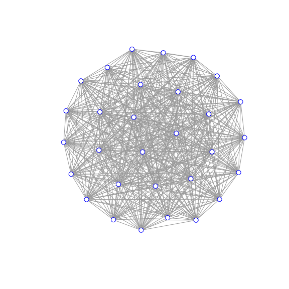

```r
g_hub = graph.adjacency(A[is_hub,is_hub],mode = "undirected")

plot(g_hub, vertex.size = 5, vertex.color = "white",
     layout = layout.fruchterman.reingold(g_hub),
     vertex.label = "",
     vertex.shape = "circle",
     vertex.frame.color = "blue")
```

However, if we inspect the correlation matrix we see evidence of two mutually antagonistic signature modules, including the signature of TBK1 - highlighted in Gayo et al. 2017. This signature module structure may suggest that the associated upstream regulators are playing coordinated roles in this antagonistic structure. This type of analysis may be useful in predicting relationships between the regulators within the context of our single-cell system.

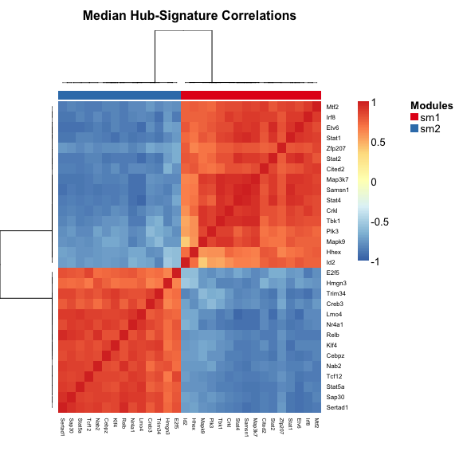

```r
# Compute hub-hub correlations per donor
rep_cor_list = sapply(levels(donor),
                      simplify = FALSE,
                      function(p) {
                        cor(t(x[is_hub,
                              donor == p]))
                        })

# Compute median hub correlation matrix
mediancor = apply(simplify2array(rep_cor_list), 1:2, median)

# Clustering median hub correlation matrix
hc = hclust(dist(1 - cor(mediancor,
                         method = "pearson")),
            method = "complete")

hub_clustering = factor(paste0("sm",cutree(hc, k = 2)))

aheatmap(
  main = "Median Hub-Signature Correlations",
  mediancor,
  breaks = 0,
  annCol = list(Modules = hub_clustering),
  annColors = list(Modules = module_cols),
  distfun = "correlation",
  hclustfun = "complete"
)
```

# 6 Other Extensions to IDR Analysis

In addition to high-level functions such as `kruskalIDRm`, `scider` implements new tools for probing lower-level IDR analysis. It was mentioned above that `est.IDRm` is the underlying function behind IDR analysis in `scider`. The arguments to this function include a matrix of signals, and initialized parameter values for the underlying fit. Consider signals from the three-replicate analysis above: log-transformed p-value from gene-level Kruskal-Wallis tests. With `est.IDRm`, we can reproduce the IDR values of this analysis exactly:

```r
signals = -log10(na.omit(idrm_kruskal$kruskal_pvals))

idr = est.IDRm(
  signals,
  mu = 2, sigma = 2, rho = 0.5, p = 0.01)

print(all(idrm_kruskal$idr$IDR == idr$IDR))
```

```
## [1] TRUE
```

## 6.1 Sub-Sampling Tests

`scider` offers another low-level function, `est.IDRm.sample`, which runs IDR analysis over various sub samples of tests. By running the analysis many times, we can evaluate the stability of our outputs. Below we can take the opportunity to compare the range of fit parameters values after we vary our initial estimates.

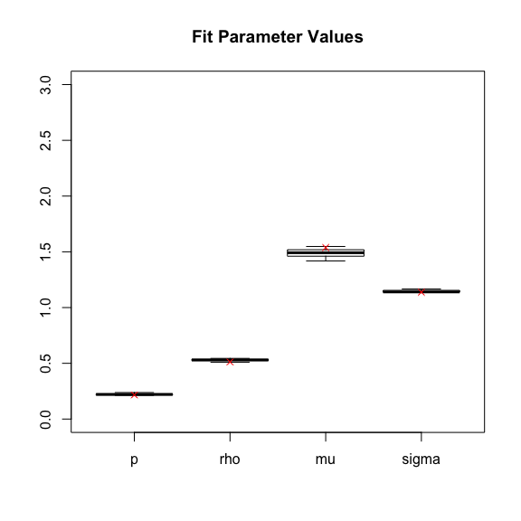

```r
idr_sample = est.IDRm.sample(x = signals,
                             frac = 0.7,
                             nsamp = 10,
                             mu = 1, sigma = 0.5,
                             rho = 0.7, p = 0.05)

bxp(idr_sample$para_bp, ylim = c(0,3), main = "Fit Parameter Values")
points(unlist(idr$para), pch = 4, col = "red")
```

The y-axis above represents parameter estimates over many samples of tests (rows). `p` represents the proportion of tests that are estimated to be reproducible. `rho` represents the correlation coefficient between reproducible test signals. `mu` is the relative signal excess in the reproducible component, while `sigma` is the relative scale of signal variance in the reproducible component.

The red X’s marks above the fit parameter values in the previous run. The box plot object exported by `est.IDRm.sample` shows us that even with our new initial parameters, the fit robustly converges on the same final values.

Another element of the output allows us to monitor the relationship between the mean probability of membership of a test to the irreproducible component and its relation to the standard deviation of those estimate across samples:

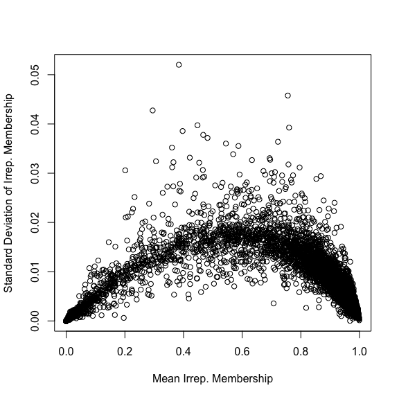

```r
plot(idr_sample$mean_idr,idr_sample$sd_idr,
     xlab = "Mean Irrep. Membership",
     ylab = "Standard Deviation of Irrep. Membership")
```

We can see that extreme membership probabilities are quite robust, while intermediate estimates are noisy and fairly unreliable.

## 6.2 Pairwise Correlation Metric

At times, it may be useful to consider pairwise signal correlations between replicates. `scider` offers a `corIDR` function that will run pairwise IDR analysis on all signals, returning the correlation parameter from the fit. This parameter translates to the correlation of signals in the reproducible fraction of signals.

```r
cor_mat_idr = corIDR(signals)
```

Plots such as the one below can be useful in discriminating outlier replicate pools: samples that exhibit lower signal correlation (e.g. < 0.5) with most replicates are reproducing signals poorly, and should be considered for removal.

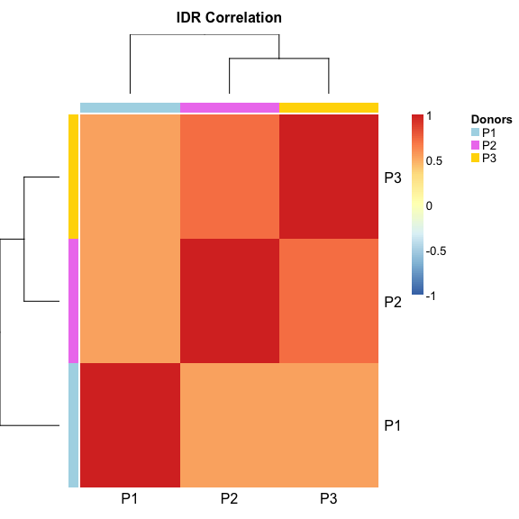

```r
aheatmap(cor_mat_idr,
         main = "IDR Correlation",
         breaks = 0,
         annCol = list(Donors = factor(levels(donor))),
         annRow = list(Donors = factor(levels(donor))),
         annColors = list(Donors = c("lightblue","violet","gold")))
```

Amit, Ido, Manuel Garber, Nicolas Chevrier, Ana Paula Leite, Yoni Donner, and et al. 2009. “Unbiased Reconstruction of a Mammalian Transcriptional Network Mediating Pathogen Responses.” *Science* 326: 257–63.

Chevrier, Nicolas, Philipp Mertins, Maxim N. Artyomov, Alex K. Shalek, Matteo Iannacone, and et al. 2011. “Systematic Discovery of Tlr Signaling Components Delineates Viral-Sensing Circuits.” *Cell* 147: 853–67.

Li, Bo, and Colin N Dewey. 2011. “RSEM: Accurate Transcript Quantification from Rna-Seq Data with or Without a Reference Genome.” *BMC Bioinformatics* 13: 323.

Li, Qunhua, James B Brown, Haiyan Huan, and Peter J. Bickel. 2011. “Measuring Reproducibility of High-Throughput Experiments.” *The Annals of Applied Statistics* 5 (3): 1752–79.

Picelli, Simone, Åsa K Björklund, Omid R Faridani, Sven Sagasser, Gösta Winberg, and Rickard Sandberg. 2013. “Smart-Seq2 for Sensitive Full-Length Transcriptome Profiling in Single Cells.” *Nature Methods* 10: 1096–8.

Walker, Bruce D, and Xu G Yu. 2013. “Unravelling the Mechanisms of Durable Control of Hiv‑1.” *Nature Reviews Immunology* 13 (july): 487–98.